# Whipping up some plots with `ggplot2`

## Themes make it way nicer

with very little effort

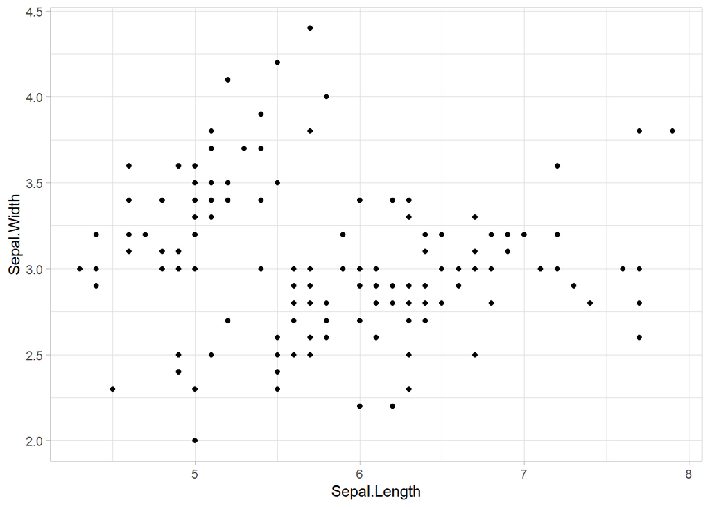

```r
ggplot(iris, aes(x=Sepal.Length, y=Sepal.Width)) +
  geom_point() +
  theme_light()
```

# `geom_jitter()`

Sometimes it makes sense to spread the data a little bit, so that points points that lay on the same coordinates are not stacked upon each other.  
Disadvantage: The points are not plotted exactly on the coordinates where they should be located. This means, that the points are visually biased.

Compare this result with `geom_point()`!

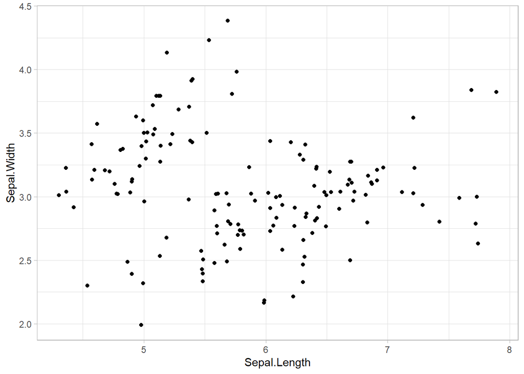

```r
ggplot(iris, aes(x=Sepal.Length, y=Sepal.Width)) +
  geom_jitter() +
  theme_light()
```

## unbiased with factor

In case you’ll use a categorical variable, the jitter doesn’t bias the view.

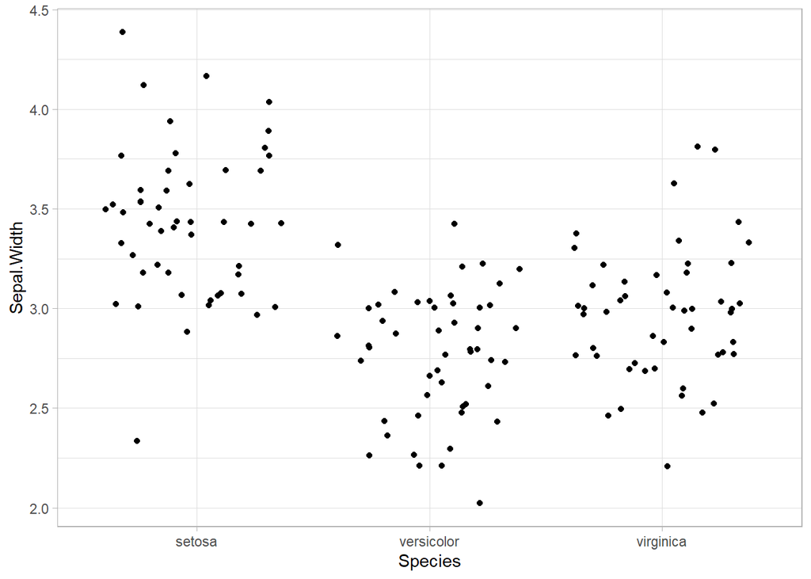

```r
ggplot(iris, aes(x=Species, y=Sepal.Width)) +
  geom_jitter() +
  theme_light()
```

In this case jitter is very usesfull. Compare this result with using `geom_point()`!

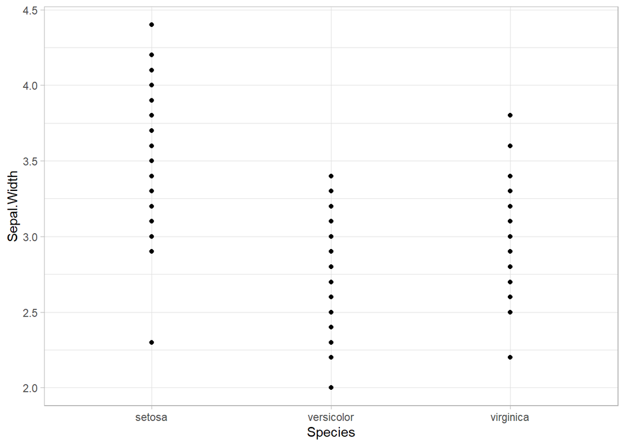

```r
ggplot(iris, aes(x=Species, y=Sepal.Width)) +
  geom_point() +
  theme_light()
```

# `geom_boxplot()`

Let’s add a boxplot over the points. We added `geom_boxplot()` after `geom_jitter()`, therefore it will lay above the points.

## with `alpha`

The argument `alpha=0.5` enables us to make the boxplot 50% transparent, so that we see the points below.

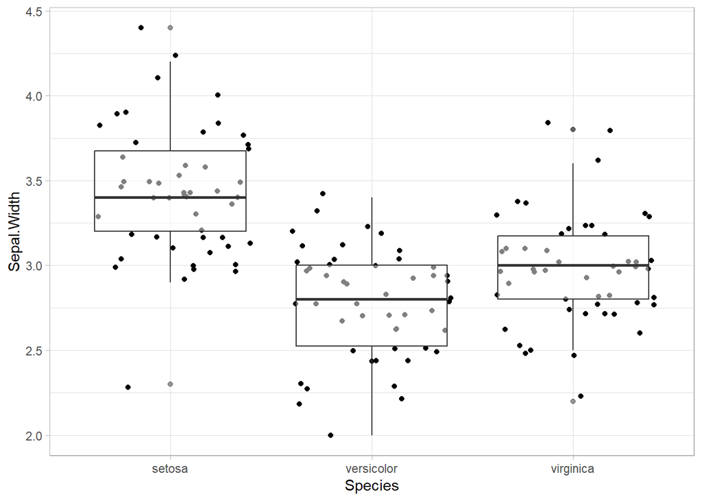

```r
ggplot(iris, aes(x=Species, y=Sepal.Width)) +
  geom_jitter() +
  geom_boxplot(alpha=0.5) +
  theme_light()
```

## nudged in its position

We can also push the boxplot aside a bit so that it doesn’t overlay the points.

Also, we can limit the width of the jitter.

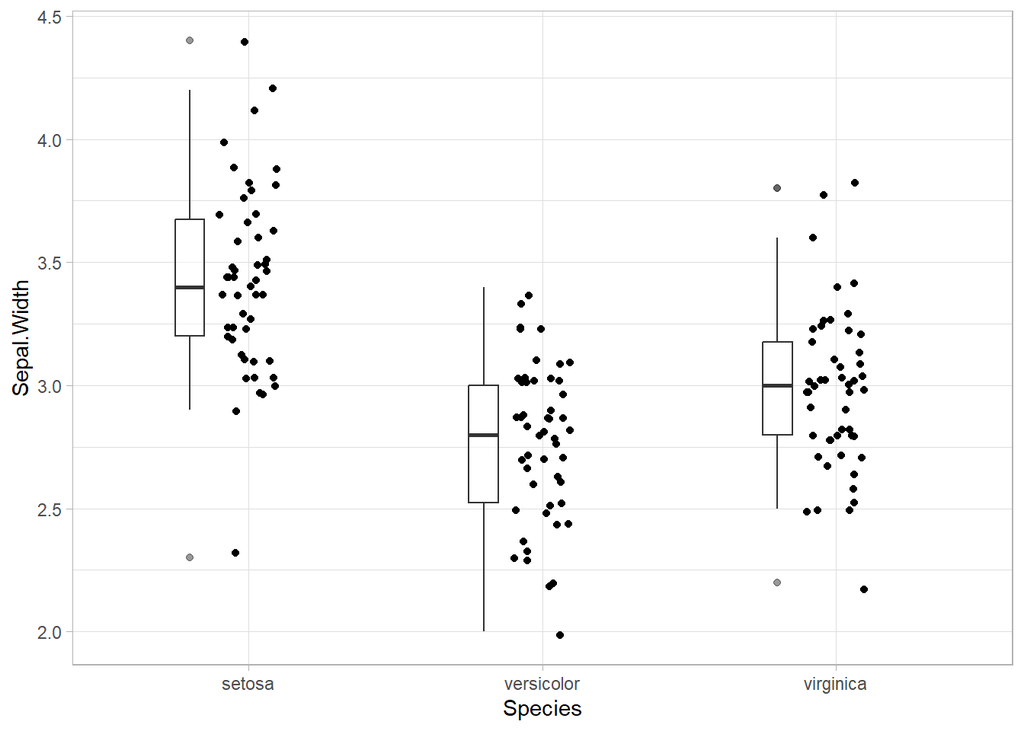

```r
ggplot(iris, aes(x=Species, y=Sepal.Width)) +
  geom_jitter(width = .1) +
  geom_boxplot(alpha=0.5,
               position = position_nudge(x=-.2),
               width=.1) +
  theme_light()
```

# `geom_violin()`

In my poinion they show the distribution of data very good (e.g. compared to boxplots).

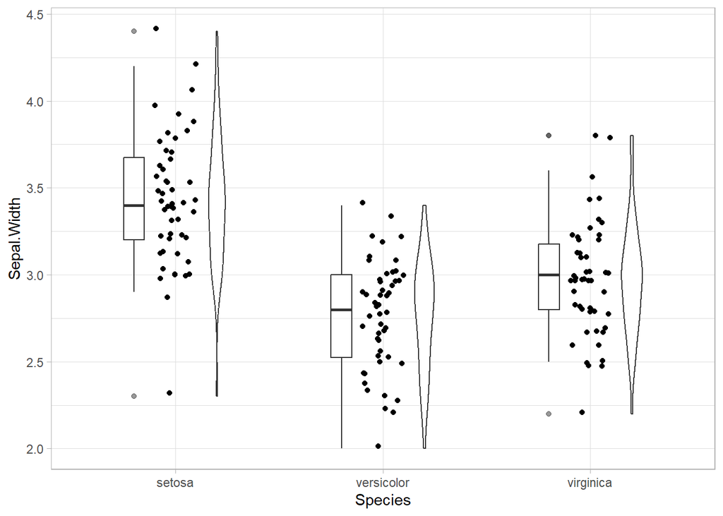

```r
ggplot(iris, aes(x=Species, y=Sepal.Width)) +
  geom_jitter(width = .1) +
  geom_boxplot(alpha=0.5,
               position = position_nudge(x=-.2),
               width=.1) +
  geom_violin(position = position_nudge(x=.2),
              width=.1) +
  theme_light()
```

# `geom_smooth()`

If you want to plot a regression line you can use `geom_smooth()`

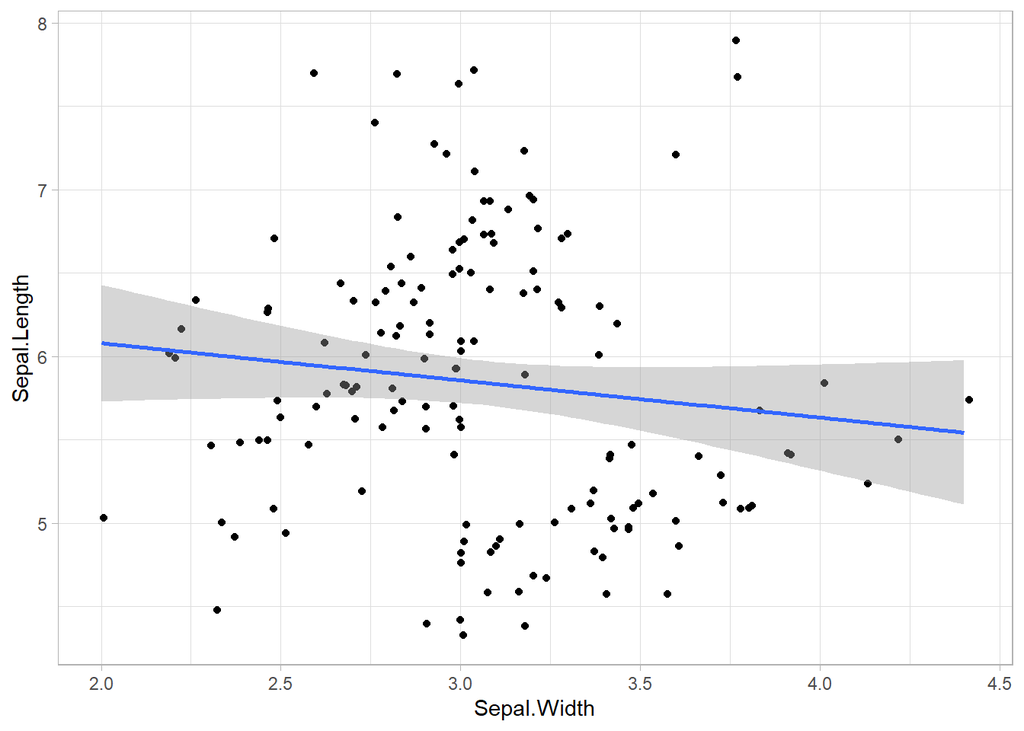

```r
ggplot(iris, aes(x=Sepal.Width, y=Sepal.Length)) +
  geom_jitter() +
  geom_smooth(method="lm") +
  theme_light()
```

## One line per group

In case you are doing “multilevel stuff”, you can plot one regression line for each group.  
You can either specify this within an aesthetics function in `geom_smooth()`…

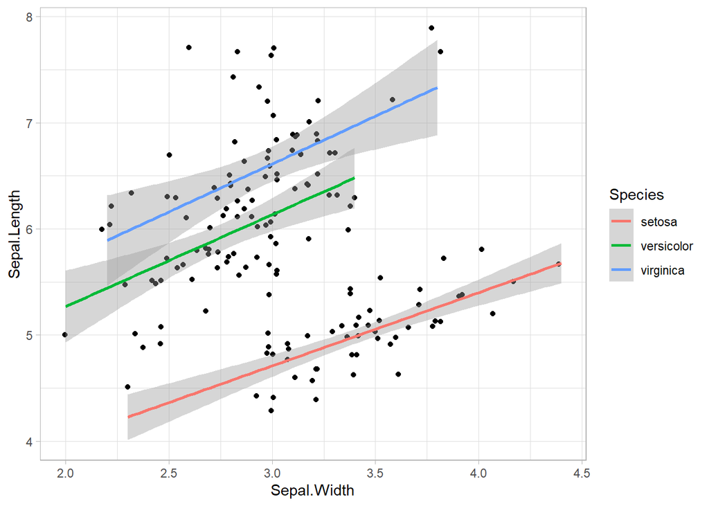

```r
ggplot(iris, aes(x=Sepal.Width, y=Sepal.Length)) +
  geom_jitter() +
  geom_smooth(aes(color=Species), method="lm") +
  theme_light()
```

… or define it in the aesthetics function at the beginning, in the `ggplot()` function.  
See the difference? If you define it in the `ggplot()` function, the coloring will be applied to all geoms (jitter and smooth).

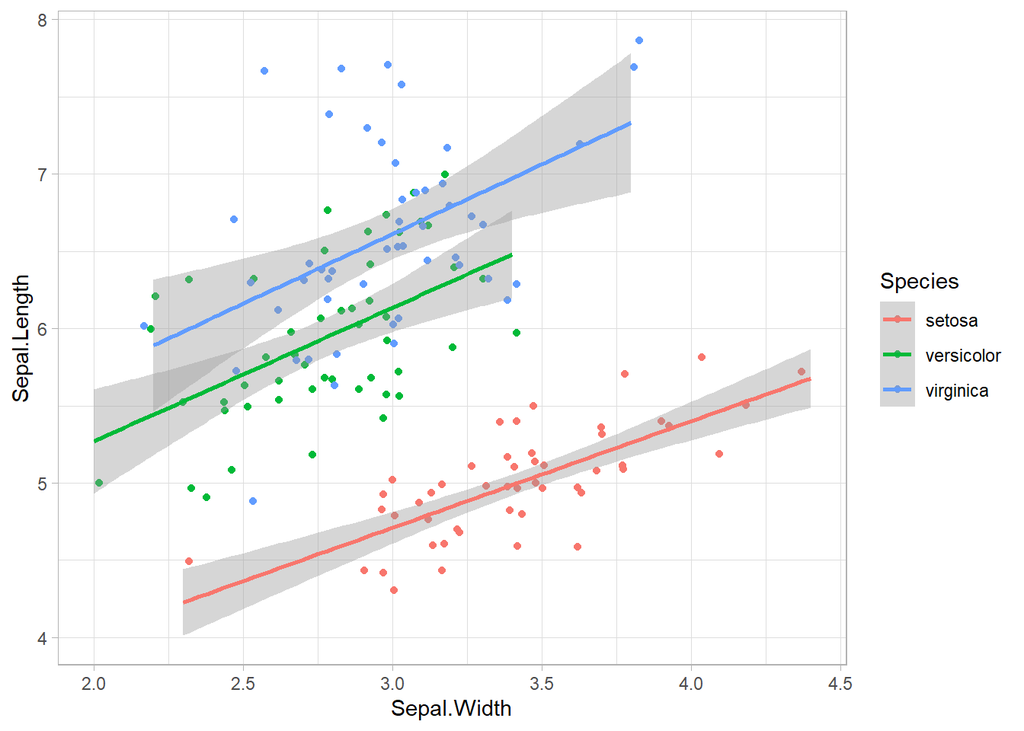

```r
ggplot(iris, aes(x=Sepal.Width, y=Sepal.Length, color=Species)) +
  geom_jitter() +
  geom_smooth(method="lm") +
  theme_light()
```

### Print-friendly (grayscale friendly)

We can also differentiate the groups by using different linetypes. Most journals only take grayscal-friendly plots.

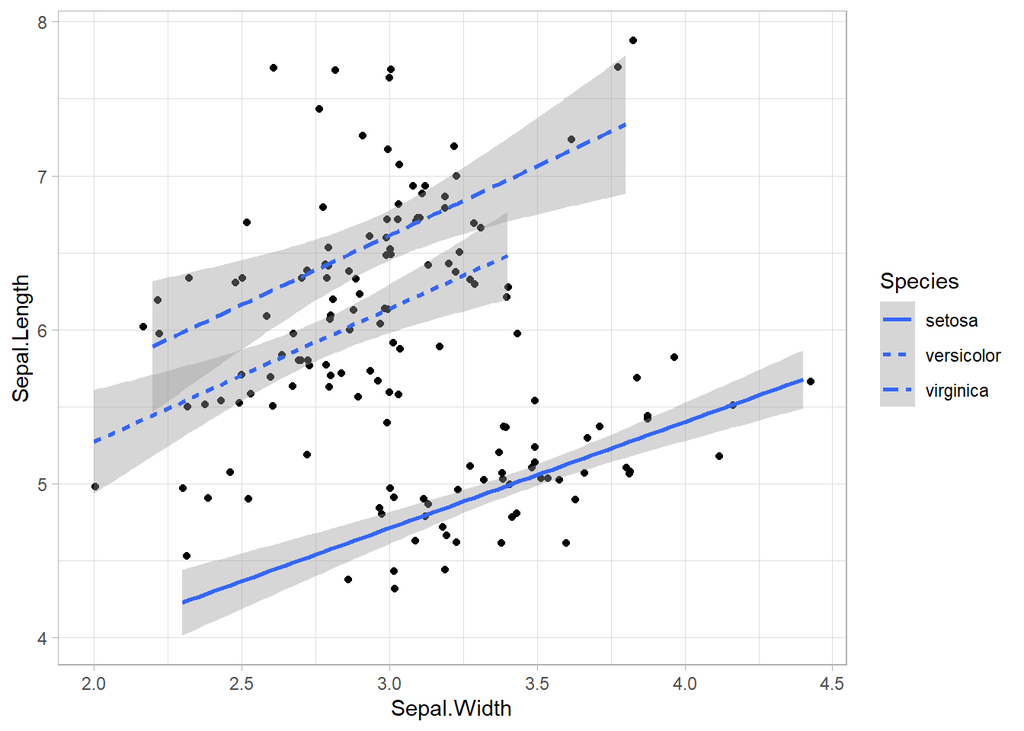

```r
ggplot(iris, aes(x=Sepal.Width, y=Sepal.Length, linetype=Species)) +
  geom_jitter() +
  geom_smooth(method="lm") +
  theme_light()
```

To actually make it grayscale, we need to define the blue lines as black.  
But wait. Doesn’t this simply differentiate between groups like above (`color=Species`)?  
No. Only if you put `color = ...` in the `aes()` function and feed it a variable to differentiate the groups.  
In this case (below), we simply tell the `geom_smooth()` function to set the color to black.

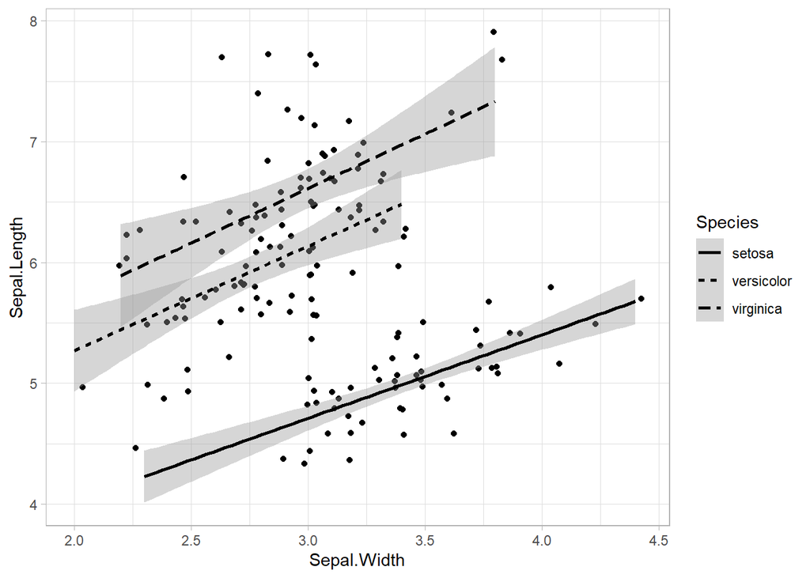

```r
ggplot(iris, aes(x=Sepal.Width, y=Sepal.Length, linetype=Species)) +
  geom_jitter() +
  geom_smooth(method="lm", color = "black") +
  theme_light()
```

OF course we can also combine two groupings (linetype and color).

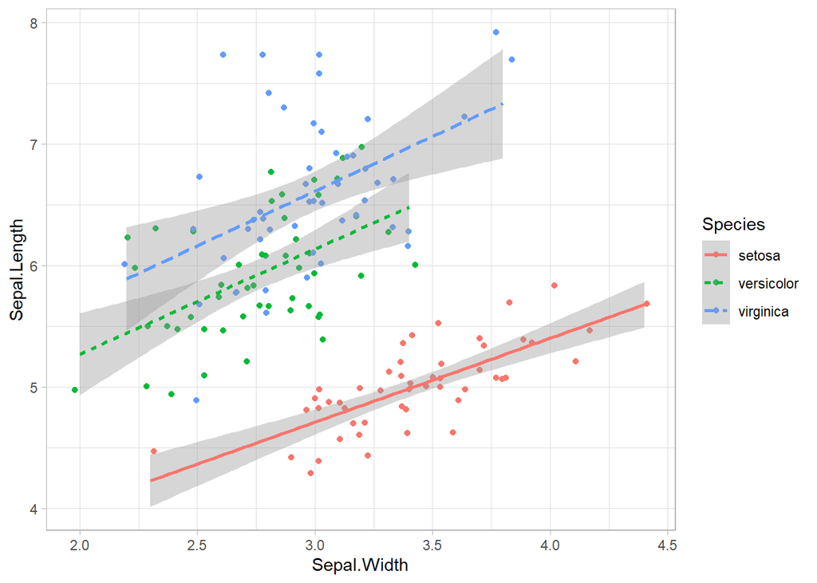

```r
ggplot(iris, aes(x=Sepal.Width, y=Sepal.Length, linetype=Species, color = Species)) +
  geom_jitter() +
  geom_smooth(method="lm") +
  theme_light()
```

### Artifically creating groups

In this case we want to compare

- subjects that lay at least one SD above the mean with
- subjects that lay at least one SD below the mean with
- subjects that lay “around the mean” (plus/minus one SD)

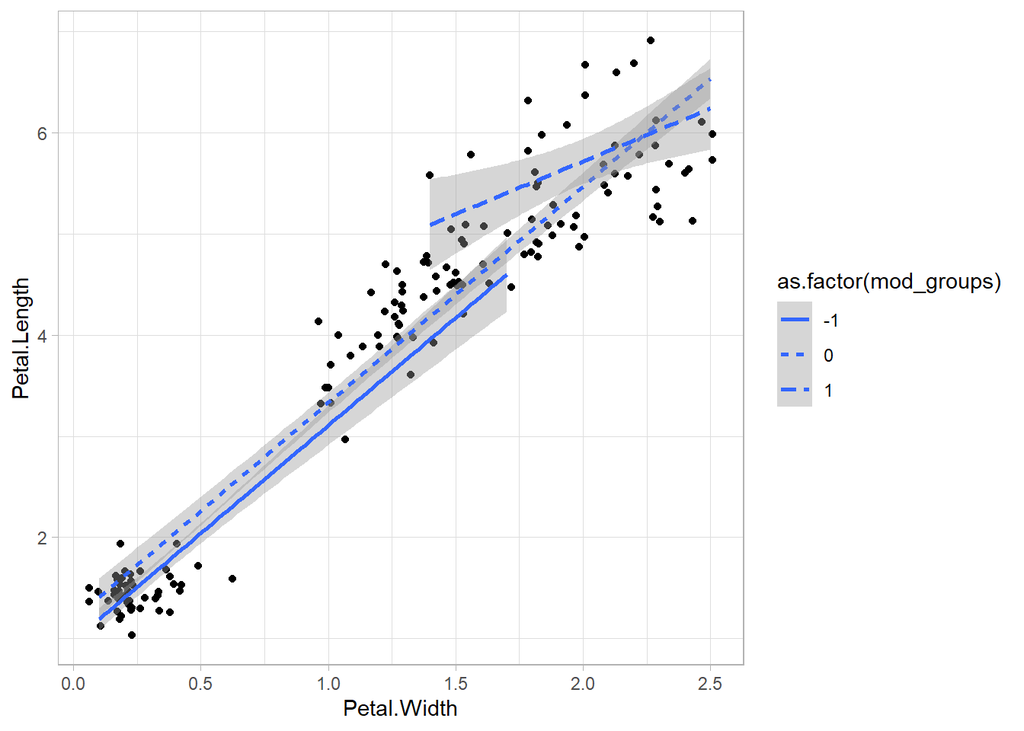

```r
interaction_sd <- iris |>
  # let's create a grouping variable with these 3 groups
  mutate(mod_groups = case_when(
                          Sepal.Length < mean(Sepal.Length) - sd(Sepal.Length) ~ -1, # group -1 SD
                          Sepal.Length > mean(Sepal.Length) + sd(Sepal.Length) ~ 1,  # group +1 SD
                          TRUE ~ 0                                                   # the rest
  ))


ggplot(interaction_sd, aes(Petal.Width, Petal.Length, linetype = as.factor(mod_groups))) +
  geom_jitter() +
  geom_smooth(method="lm") +
  theme_light()
```